# DECISION TREES and LOGISTIC REGRESSION to predict the GRADE (no pass/pass)

Bogdan Tanasa

#### **1. INTRODUCTION**

#### **2. DATA EXPLORATION**

#### **3. DATA SELECTION**

#### **4. DATA FILTERING**

#### **5. TRAINING AND TEST SETS**

#### **6. PRE-PROCESSING THE DATA**

#### **7. PERFORMING THE TRAINING**

#### **8. MAKING THE PREDICTIONS**

#### **9. THE CONFUSION MATRIX**

#### **10. THE LOGISTIC REGRESSION MODEL AND CONCLUSIONS**

#### **1. INTRODUCTION**

We are using the data from **UCI** : !( https://archive.ics.uci.edu/ml/datasets/Student+Performance )

We are reading a file about **STUDENTS**, and we aim to predict whether they have passed or not the exams **(PASS/no_PASS)**;

The attributes in the **INPUT FILE** are the following :

- 1 school - student’s school (binary: “GP” - Gabriel Pereira or “MS” - Mousinho da Silveira)
- 2 sex - student’s sex (binary: “F” - female or “M” - male)
- 3 age - student’s age (numeric: from 15 to 22)
- 4 address - student’s home address type (binary: “U” - urban or “R” - rural)
- 5 famsize - family size (binary: “LE3” - less or equal to 3 or “GT3” - greater than 3)
- 6 Pstatus - parent’s cohabitation status (binary: “T” - living together or “A” - apart)
- 7 Medu - mother’s education (numeric: 0 - none, 1 - primary education (4th grade), 2 - 5th to 9th grade, 3 - secondary education or 4 - higher education)
- 8 Fedu - father’s education (numeric: 0 - none, 1 - primary education (4th grade), 2 - 5th to 9th grade, 3 - secondary education or 4 - higher education)
- 9 Mjob - mother’s job (nominal: “teacher”, “health” care related, civil “services” (e.g. administrative or police), “at_home” or “other”)
- 10 Fjob - father’s job (nominal: “teacher”, “health” care related, civil “services” (e.g. administrative or police), “at_home” or “other”)
- 11 reason - reason to choose this school (nominal: close to “home”, school “reputation”, “course” preference or “other”)
- 12 guardian - student’s guardian (nominal: “mother”, “father” or “other”)
- 13 traveltime - home to school travel time (numeric: 1 - <15 min., 2 - 15 to 30 min., 3 - 30 min. to 1 hour, or 4 - >1 hour)
- 14 studytime - weekly study time (numeric: 1 - <2 hours, 2 - 2 to 5 hours, 3 - 5 to 10 hours, or 4 - >10 hours)
- 15 failures - number of past class failures (numeric: n if 1<=n<3, else 4)
- 16 schoolsup - extra educational support (binary: yes or no)
- 17 famsup - family educational support (binary: yes or no)
- 18 paid - extra paid classes within the course subject (Math or Portuguese) (binary: yes or no)
- 19 activities - extra-curricular activities (binary: yes or no)
- 20 nursery - attended nursery school (binary: yes or no)
- 21 higher - wants to take higher education (binary: yes or no)
- 22 internet - Internet access at home (binary: yes or no)
- 23 romantic - with a romantic relationship (binary: yes or no)
- 24 famrel - quality of family relationships (numeric: from 1 - very bad to 5 - excellent)
- 25 freetime - free time after school (numeric: from 1 - very low to 5 - very high)
- 26 goout - going out with friends (numeric: from 1 - very low to 5 - very high)
- 27 Dalc - workday alcohol consumption (numeric: from 1 - very low to 5 - very high)
- 28 Walc - weekend alcohol consumption (numeric: from 1 - very low to 5 - very high)
- 29 health - current health status (numeric: from 1 - very bad to 5 - very good)
- 30 absences - number of school absences (numeric: from 0 to 93)

#### **2. DATA EXPLORATION**

```r
library(ggplot2)
library(reshape2)
library(readxl)
library(dplyr)
library(tidyr)
library(purrr)
library(ggpubr)
library(broom)
library(tibble)
library(class)
library(gmodels)
library(caret)
library(e1071)
library(ISLR)
library(pROC)
library(lattice)
library(kknn)
library(multiROC)
library(MLeval)
library(AppliedPredictiveModeling)
library(corrplot)
library(Hmisc)

######################################################
######################################################
######################################################
######################################################

FILE1="student.mat.txt"

######################################################
######################################################
######################################################
######################################################

student <- read.delim(FILE1, sep="\t", header=T, stringsAsFactors=F)

######################################################
######################################################

summary(student)
```

```
##     school              sex                 age         address
##  Length:395         Length:395         Min.   :15.0   Length:395
##  Class :character   Class :character   1st Qu.:16.0   Class :character
##  Mode  :character   Mode  :character   Median :17.0   Mode  :character
##                                        Mean   :16.7
##                                        3rd Qu.:18.0
##                                        Max.   :22.0
##    famsize            Pstatus               Medu            Fedu
##  Length:395         Length:395         Min.   :0.000   Min.   :0.000
##  Class :character   Class :character   1st Qu.:2.000   1st Qu.:2.000
##  Mode  :character   Mode  :character   Median :3.000   Median :2.000
##                                        Mean   :2.749   Mean   :2.522
##                                        3rd Qu.:4.000   3rd Qu.:3.000
##                                        Max.   :4.000   Max.   :4.000
##      Mjob               Fjob              reason            guardian
##  Length:395         Length:395         Length:395         Length:395
##  Class :character   Class :character   Class :character   Class :character
##  Mode  :character   Mode  :character   Mode  :character   Mode  :character
##
##
##
##    traveltime      studytime        failures       schoolsup
##  Min.   :1.000   Min.   :1.000   Min.   :0.0000   Length:395
##  1st Qu.:1.000   1st Qu.:1.000   1st Qu.:0.0000   Class :character
##  Median :1.000   Median :2.000   Median :0.0000   Mode  :character
##  Mean   :1.448   Mean   :2.035   Mean   :0.3342
##  3rd Qu.:2.000   3rd Qu.:2.000   3rd Qu.:0.0000
##  Max.   :4.000   Max.   :4.000   Max.   :3.0000
##     famsup              paid            activities          nursery
##  Length:395         Length:395         Length:395         Length:395
##  Class :character   Class :character   Class :character   Class :character
##  Mode  :character   Mode  :character   Mode  :character   Mode  :character
##
##
##
##     higher            internet           romantic             famrel
##  Length:395         Length:395         Length:395         Min.   :1.000
##  Class :character   Class :character   Class :character   1st Qu.:4.000
##  Mode  :character   Mode  :character   Mode  :character   Median :4.000
##                                                           Mean   :3.944
```

[output cut: 8 more lines]

```
##  Max.   :5.000   Max.   :5.000   Max.   :5.000   Max.   :5.000
##      health         absences            G1              G2
##  Min.   :1.000   Min.   : 0.000   Min.   : 3.00   Min.   : 0.00
##  1st Qu.:3.000   1st Qu.: 0.000   1st Qu.: 8.00   1st Qu.: 9.00
##  Median :4.000   Median : 4.000   Median :11.00   Median :11.00
##  Mean   :3.554   Mean   : 5.709   Mean   :10.91   Mean   :10.71
##  3rd Qu.:5.000   3rd Qu.: 8.000   3rd Qu.:13.00   3rd Qu.:13.00
##  Max.   :5.000   Max.   :75.000   Max.   :19.00   Max.   :19.00
##        G3
##  Min.   : 0.00
##  1st Qu.: 8.00
##  Median :11.00
##  Mean   :10.42
##  3rd Qu.:14.00
##  Max.   :20.00
```

```r
str(student)
```

```
## 'data.frame':    395 obs. of  33 variables:
##  $ school    : chr  "GP" "GP" "GP" "GP" ...
##  $ sex       : chr  "F" "F" "F" "F" ...
##  $ age       : int  18 17 15 15 16 16 16 17 15 15 ...
##  $ address   : chr  "U" "U" "U" "U" ...
##  $ famsize   : chr  "GT3" "GT3" "LE3" "GT3" ...
##  $ Pstatus   : chr  "A" "T" "T" "T" ...
##  $ Medu      : int  4 1 1 4 3 4 2 4 3 3 ...
##  $ Fedu      : int  4 1 1 2 3 3 2 4 2 4 ...
##  $ Mjob      : chr  "at_home" "at_home" "at_home" "health" ...
##  $ Fjob      : chr  "teacher" "other" "other" "services" ...
##  $ reason    : chr  "course" "course" "other" "home" ...
##  $ guardian  : chr  "mother" "father" "mother" "mother" ...
##  $ traveltime: int  2 1 1 1 1 1 1 2 1 1 ...
##  $ studytime : int  2 2 2 3 2 2 2 2 2 2 ...
```

[output cut: 19 more lines]

```r
class(student)
```

```
## [1] "data.frame"
```

Here we are starting to display the data for visual exploration.

```r
####################################################################################################
####################################################################################################
# 1 school - student's school (binary: "GP" - Gabriel Pereira or "MS" - Mousinho da Silveira)

unique(student$school)
```

```
## [1] "GP" "MS"
```

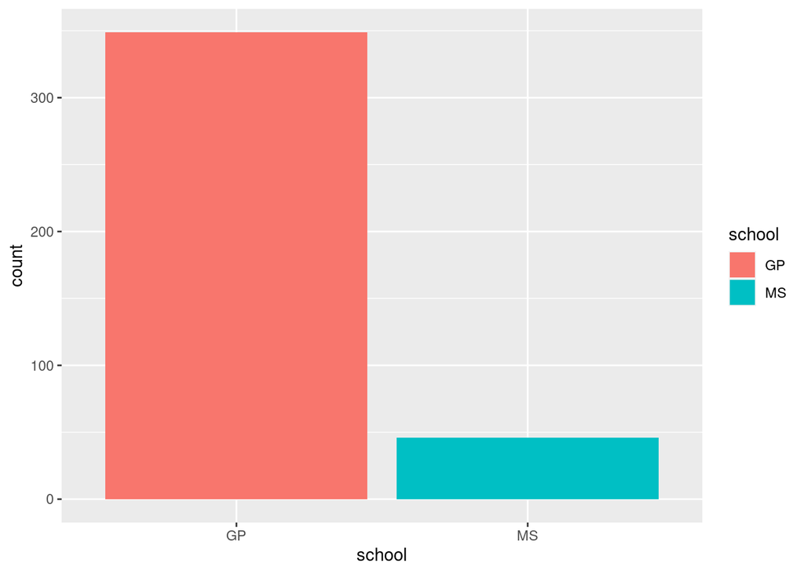

```r
ggplot(data = student) +
       geom_bar(mapping = aes(x=school, fill=school))
```

```r
# ggsave("display.1.school.png")
student$school = as.factor(student$school)

############################################################################################################
############################################################################################################
# 2 sex - student's sex (binary: "F" - female or "M" - male)

unique(student$sex)
```

```
## [1] "F" "M"
```

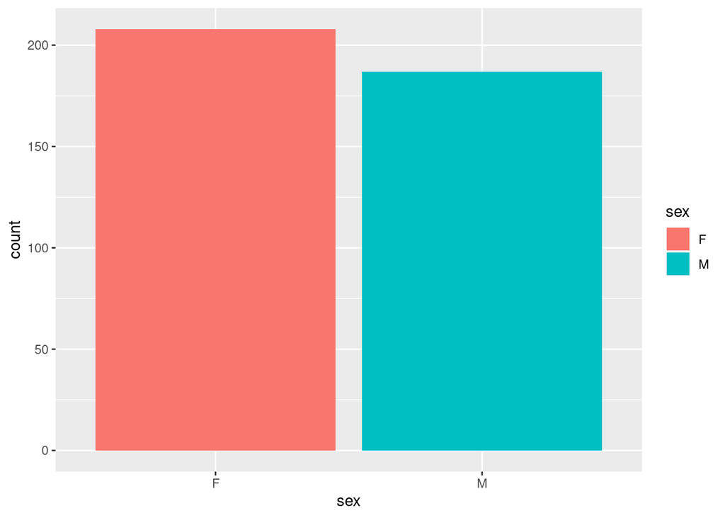

```r
ggplot(data = student) +
       geom_bar(mapping = aes(x=sex , fill=sex))
```

```r
# ggsave("display.2.sex.png")
student$sex = as.factor(student$sex)

############################################################################################################
############################################################################################################
# 3 age - student's age (numeric: from 15 to 22)

unique(student$age)
```

```
## [1] 18 17 15 16 19 22 20 21
```

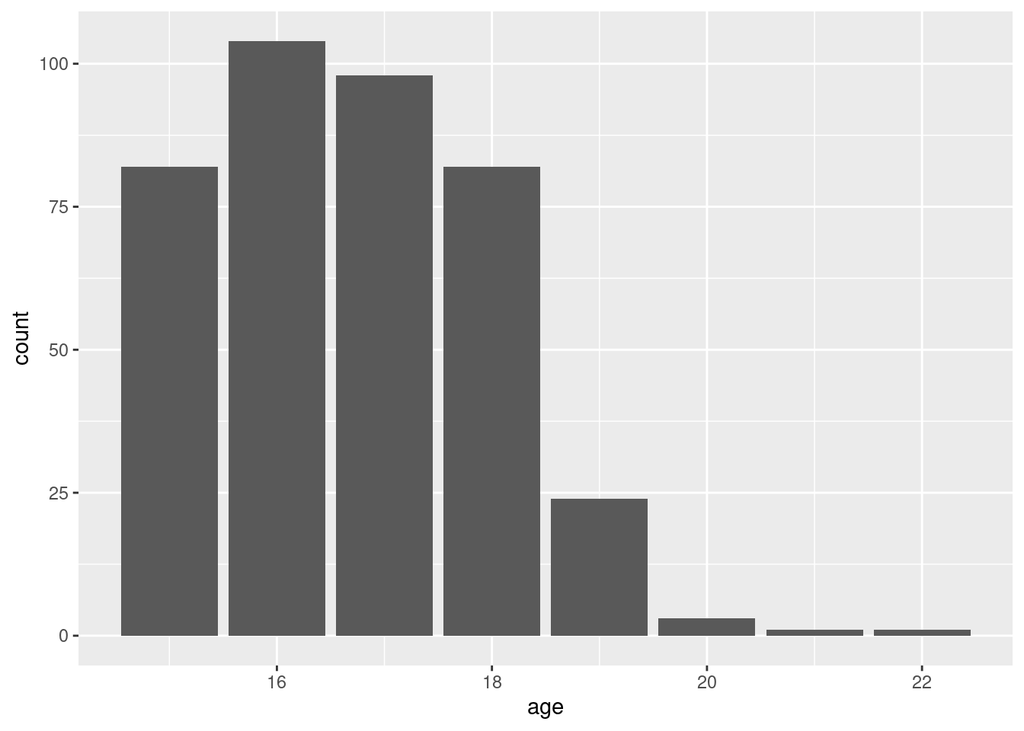

```r
ggplot(data = student) +
       geom_bar(mapping = aes(x=age , fill=age))
```

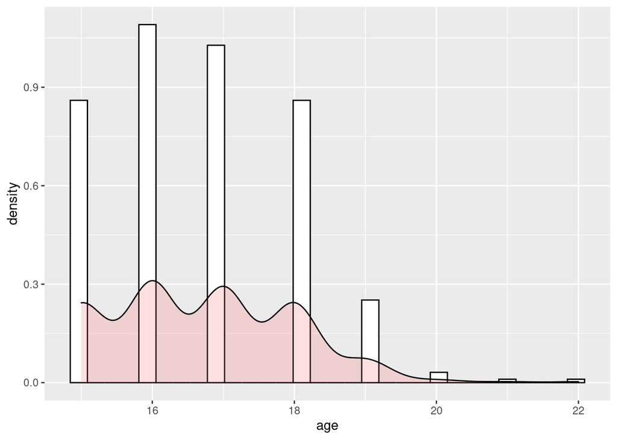

```r
ggplot(data=student, aes(x=age)) +
      geom_histogram(aes(y=..density..), colour="black", fill="white")+
      geom_density(alpha=.2, fill="#FF6666")
```

```r
# ggsave("display.3.age.png")
# AGE is already on the numerical scale !!
student$age = as.integer(student$age)

############################################################################################################
############################################################################################################
# 4 address - student's home address type (binary: "U" - urban or "R" - rural)

unique(student$address) ## [1] "U" "R"
```

```
## [1] "U" "R"
```

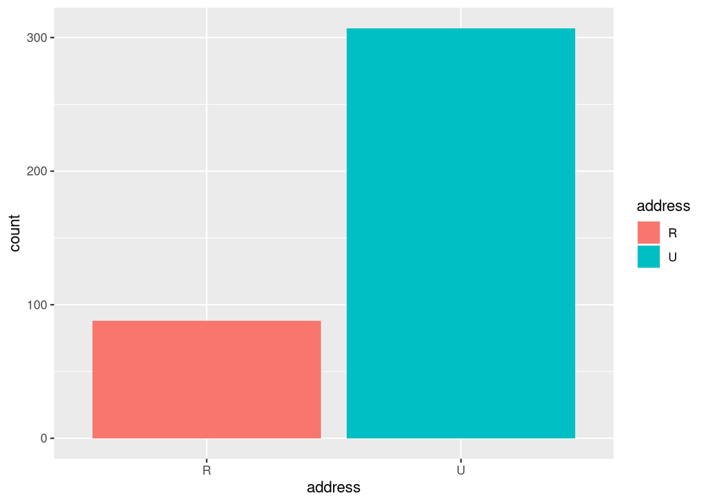

```r
ggplot(data = student) +
       geom_bar(mapping = aes(x=address, fill=address))
```

```r
# ggsave("display.4.address.png")
student$address = as.factor(student$address)

############################################################################################################
############################################################################################################
# 5 famsize - family size (binary: "LE3" - less or equal to 3 or "GT3" - greater than 3)

unique(student$famsize)
```

```
## [1] "GT3" "LE3"
```

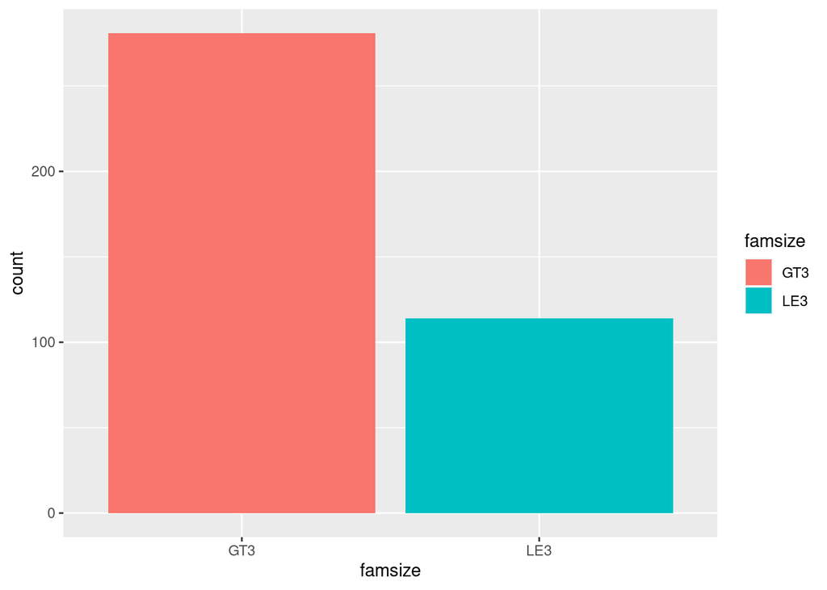

```r
ggplot(data = student) +
       geom_bar(mapping = aes(x=famsize, fill=famsize))
```

```r
# ggsave("display.5.famsize.png")
student$famsize = as.factor(student$famsize)

############################################################################################################
############################################################################################################
# 6 Pstatus - parent's cohabitation status (binary: "T" - living together or "A" - apart)

unique(student$Pstatus)
```

```
## [1] "A" "T"
```

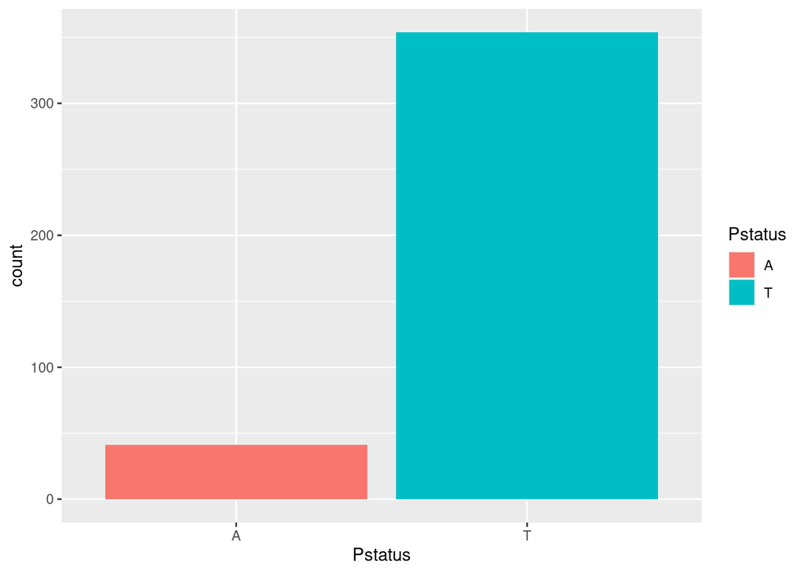

```r
ggplot(data = student) +
       geom_bar(mapping = aes(x=Pstatus, fill=Pstatus))
```

```r
# ggsave("display.6.Pstatus.png")
student$Pstatus = as.factor(student$Pstatus)

############################################################################################################
############################################################################################################
# 7 Medu - mother's education (numeric: 0 - none,  1 - primary education (4th grade), 2 â€“ 5th to 9th grade, 3 â€“ secondary education or 4 â€“ higher education)

unique(student$Medu)
```

```
## [1] 4 1 3 2 0
```

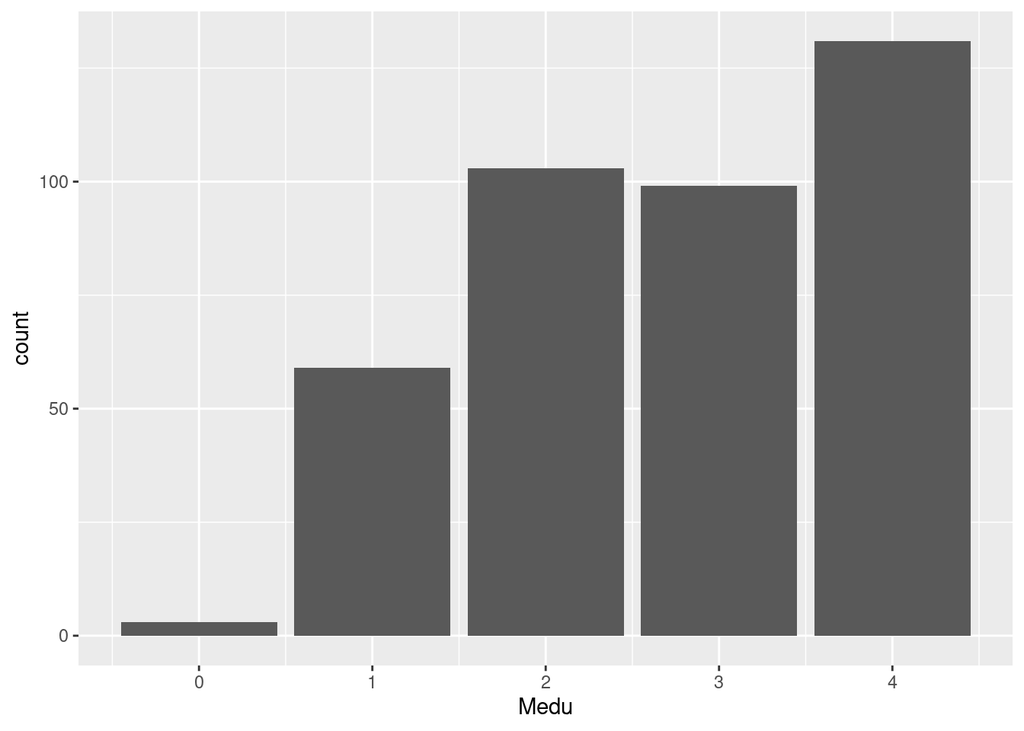

```r
ggplot(data = student) +
       geom_bar(mapping = aes(x=Medu, fill=Medu))
```

```r
# ggsave("display.7.Medu.png")
# we may wanna use the numerical values in various regression models
student$Medu = as.integer(student$Medu)

############################################################################################################
############################################################################################################
# 8 Fedu - father's education (numeric: 0 - none,  1 - primary education (4th grade), 2 â€“ 5th to 9th grade, 3 â€“ secondary education or 4 â€“ higher education)

unique(student$Fedu)
```

```
## [1] 4 1 2 3 0
```

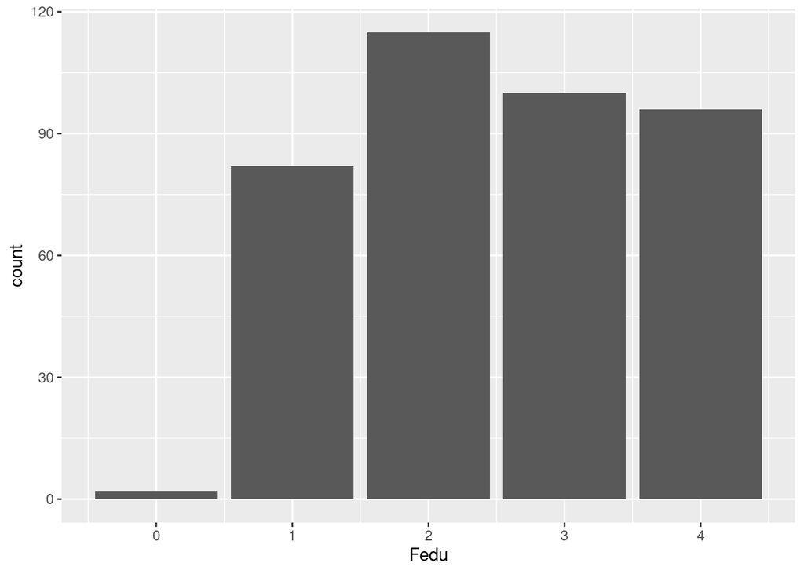

```r
ggplot(data = student) +
       geom_bar(mapping = aes(x=Fedu, fill=Fedu))
```

```r
# ggsave("display.8.Fedu.png")
# we may wanna use the numerical values in various regression models
student$Fedu = as.integer(student$Fedu)

############################################################################################################
############################################################################################################
# 9 Mjob - mother's job (nominal: "teacher", "health" care related, civil "services" (e.g. administrative or police), "at_home" or "other")

unique(student$Mjob)
```

```
## [1] "at_home"  "health"   "other"    "services" "teacher"
```

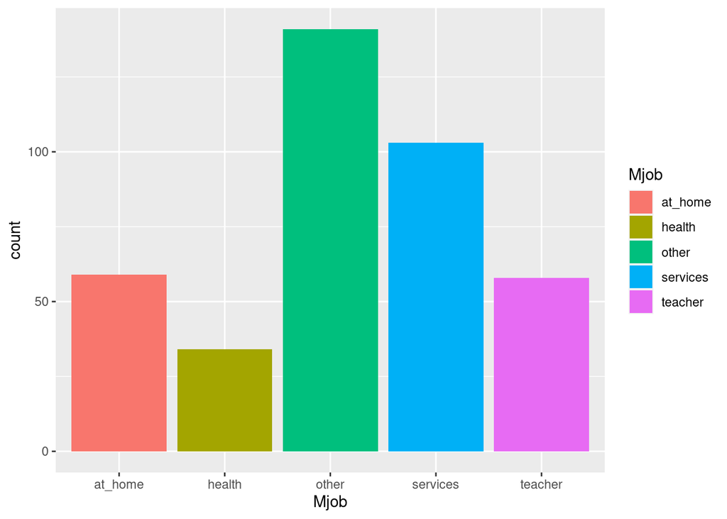

```r
ggplot(data = student) +
       geom_bar(mapping = aes(x=Mjob, fill=Mjob))
```

```r
# ggsave("display.9.Mjob.png")
student$Mjob = as.factor(student$Mjob)

############################################################################################################
############################################################################################################
# 10 Fjob - father's job (nominal: "teacher", "health" care related, civil "services" (e.g. administrative or police), "at_home" or "other")

unique(student$Fjob)
```

```
## [1] "teacher"  "other"    "services" "health"   "at_home"
```

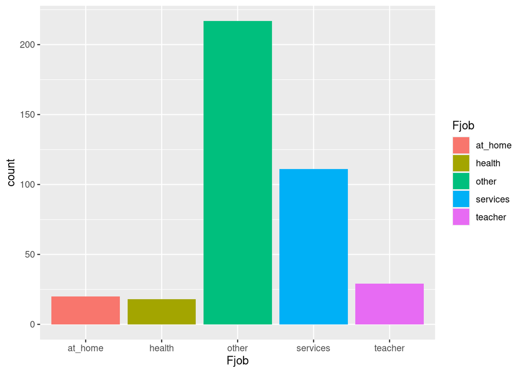

```r
ggplot(data = student) +
       geom_bar(mapping = aes(x=Fjob, fill=Fjob))
```

```r
# ggsave("display.10.Fjob.png")
student$Fjob = as.factor(student$Fjob)

############################################################################################################
############################################################################################################
# 11 reason - reason to choose this school (nominal: close to "home", school "reputation", "course" preference or "other")

unique(student$reason)
```

```
## [1] "course"     "other"      "home"       "reputation"
```

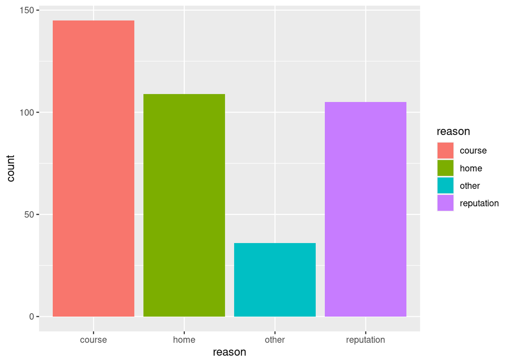

```r
ggplot(data = student) +
       geom_bar(mapping = aes(x=reason, fill=reason))
```

```r
# ggsave("display.11.reason.png")
student$reason = as.factor(student$reason)

############################################################################################################
############################################################################################################
# 12 guardian - student's guardian (nominal: "mother", "father" or "other")

unique(student$guardian)
```

```
## [1] "mother" "father" "other"
```

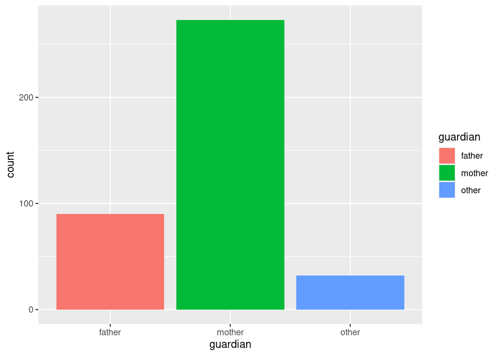

```r
ggplot(data = student) +
       geom_bar(mapping = aes(x=guardian, fill=guardian))
```

```r
# ggsave("display.12.guardian.png")
student$guardian = as.factor(student$guardian)

############################################################################################################
############################################################################################################
# 13 traveltime - home to school travel time (numeric: 1 - <15 min., 2 - 15 to 30 min., 3 - 30 min. to 1 hour, or 4 - >1 hour)

unique(student$traveltime)
```

```
## [1] 2 1 3 4
```

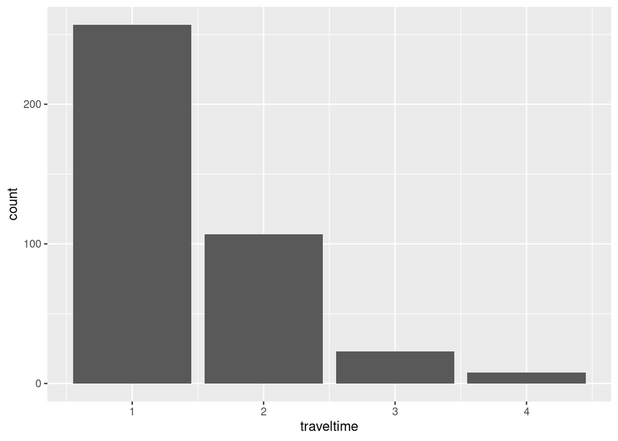

```r
ggplot(data = student) +
       geom_bar(mapping = aes(x=traveltime, fill=traveltime))
```

```r
# ggsave("display.13.traveltime.png")
# we may wanna use the NUMERICAL VALUES :
student$traveltime = as.integer(student$traveltime)

############################################################################################################
############################################################################################################
# 14 studytime - weekly study time (numeric: 1 - <2 hours, 2 - 2 to 5 hours, 3 - 5 to 10 hours, or 4 - >10 hours)

unique(student$studytime)
```

```
## [1] 2 3 1 4
```

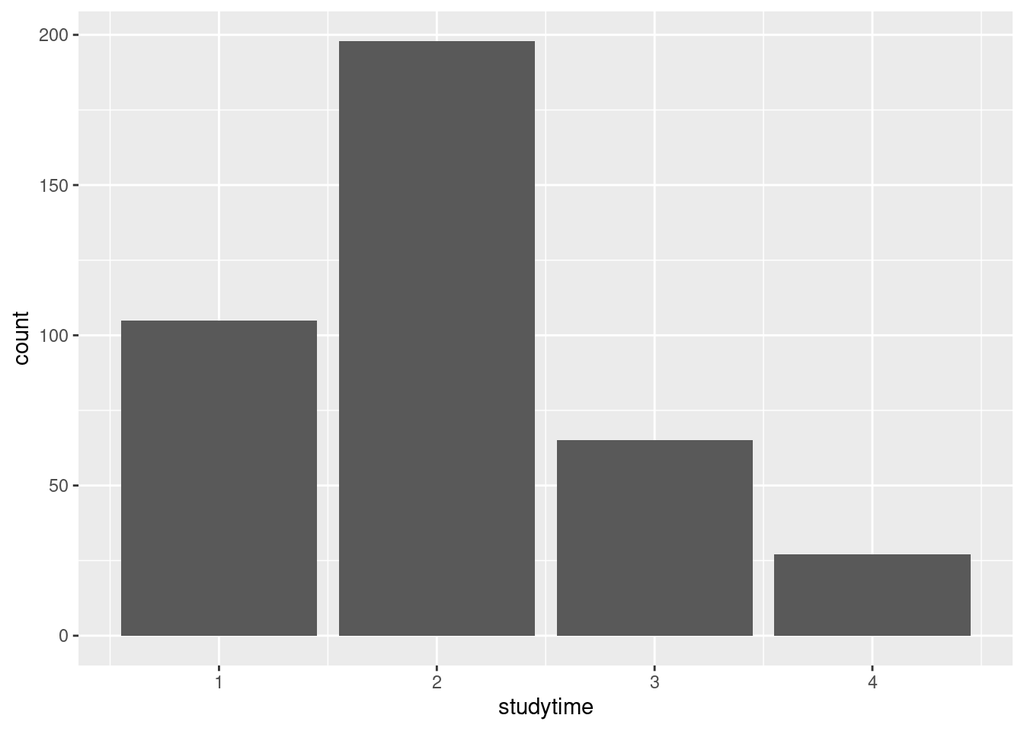

```r
ggplot(data = student) +
       geom_bar(mapping = aes(x=studytime, fill=studytime))
```

```r
# ggsave("display.14.studytime.png")
# we may wanna use the NUMERICAL VALUES :
student$studytime = as.integer(student$studytime)

############################################################################################################
############################################################################################################
# 15 failures - number of past class failures (numeric: n if 1<=n<3, else 4)

unique(student$failures)
```

```
## [1] 0 3 2 1
```

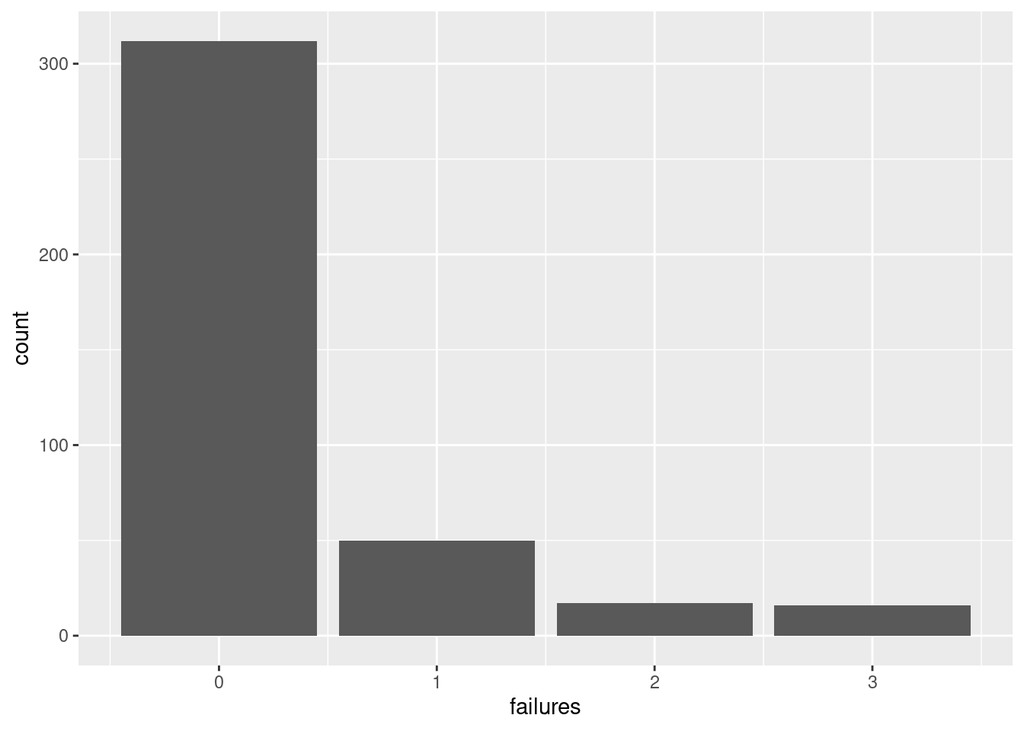

```r
ggplot(data = student) +
       geom_bar(mapping = aes(x=failures, fill=failures))
```

```r
# ggsave("display.15.failures.png")
# we may wanna use the NUMERICAL VALUES :
student$failures = as.integer(student$failures)

############################################################################################################
############################################################################################################
# 16 schoolsup - extra educational support (binary: yes or no)

unique(student$schoolsup)
```

```
## [1] "yes" "no"
```

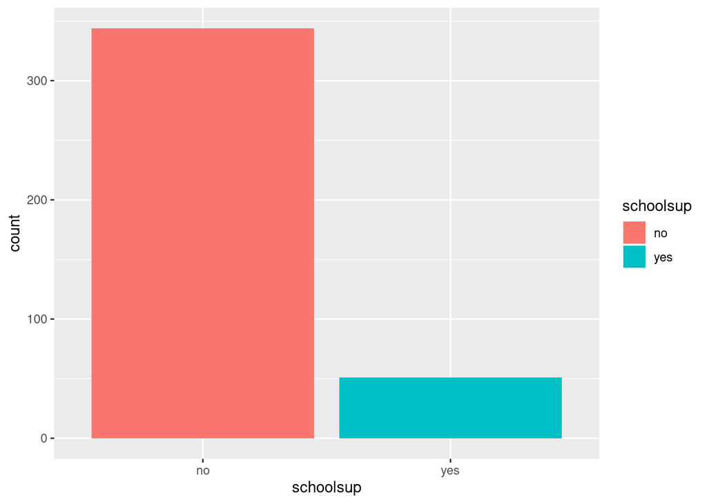

```r
ggplot(data = student) +
       geom_bar(mapping = aes(x=schoolsup, fill=schoolsup))
```

```r
# ggsave("display.16.schoolsup.png")
student$schoolsup = as.factor(student$schoolsup)

############################################################################################################
############################################################################################################
# 17 famsup - family educational support (binary: yes or no)

unique(student$famsup)
```

```
## [1] "no"  "yes"
```

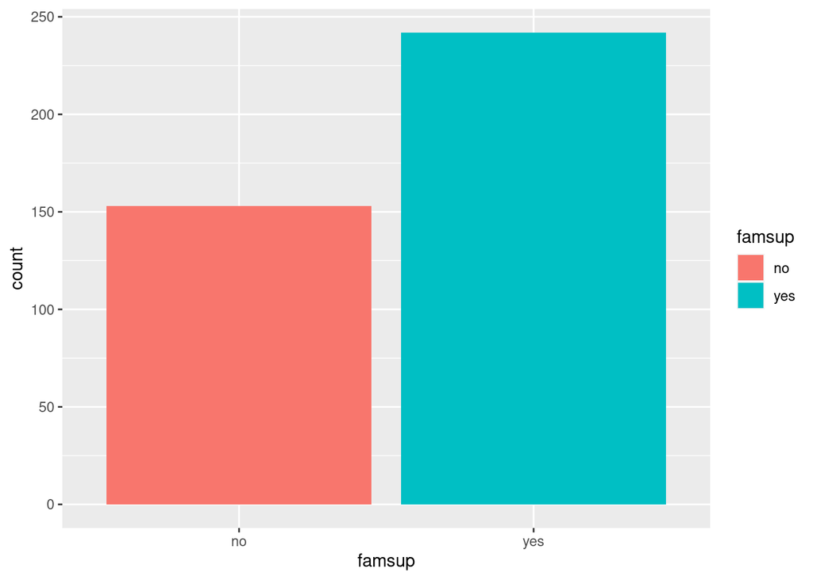

```r
ggplot(data = student) +
       geom_bar(mapping = aes(x=famsup, fill=famsup))
```

```r
# ggsave("display.17.famsup.png")
student$famsup = as.factor(student$famsup)

############################################################################################################
############################################################################################################
# 18 paid - extra paid classes within the course subject (Math or Portuguese) (binary: yes or no)

unique(student$paid)
```

```
## [1] "no"  "yes"
```

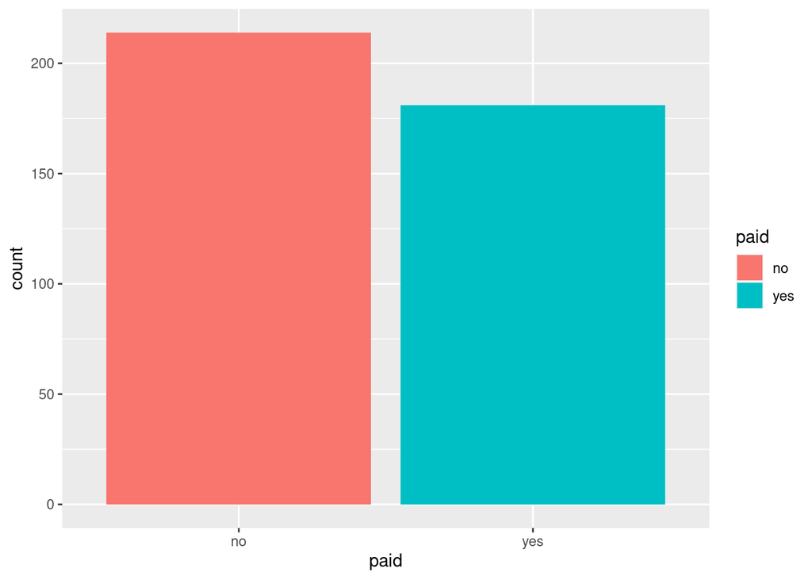

```r
ggplot(data = student) +
       geom_bar(mapping = aes(x=paid, fill=paid))
```

```r
# ggsave("display.18.paid.png")
student$paid = as.factor(student$paid)

############################################################################################################
############################################################################################################
# 19 activities - extra-curricular activities (binary: yes or no)

unique(student$activities)
```

```
## [1] "no"  "yes"
```

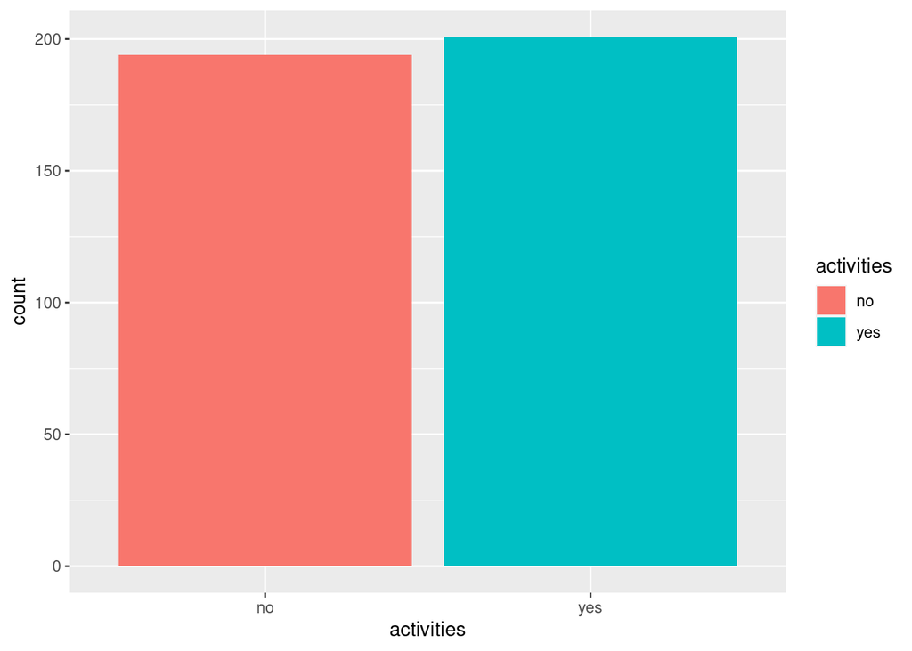

```r
ggplot(data = student) +
       geom_bar(mapping = aes(x=activities, fill=activities))
```

```r
# ggsave("display.19.activities.png")
student$activities = as.factor(student$activities)

############################################################################################################
############################################################################################################
# 20 nursery - attended nursery school (binary: yes or no)

unique(student$nursery)
```

```
## [1] "yes" "no"
```

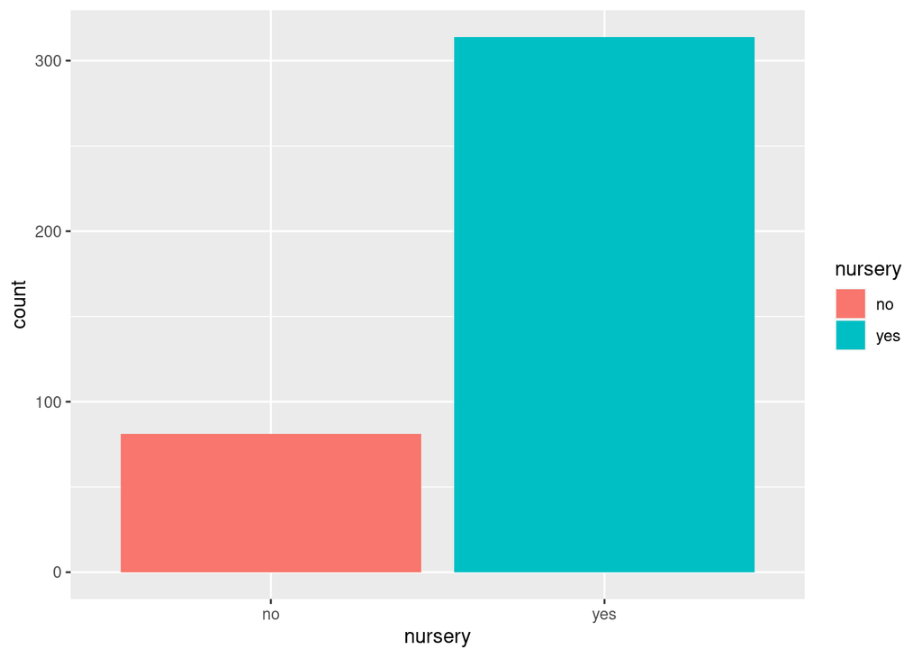

```r
ggplot(data = student) +
       geom_bar(mapping = aes(x=nursery, fill=nursery))
```

```r
# ggsave("display.20.nursery.png")
student$nursery = as.factor(student$nursery)

############################################################################################################
############################################################################################################
# 21 higher - wants to take higher education (binary: yes or no)

unique(student$higher)
```

```
## [1] "yes" "no"
```

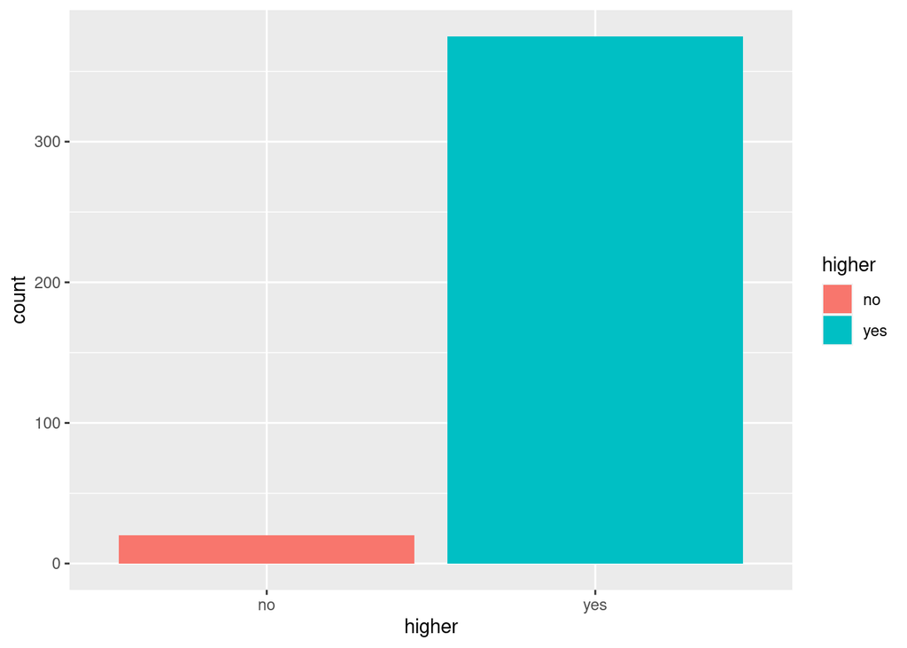

```r
ggplot(data = student) +
       geom_bar(mapping = aes(x=higher, fill=higher))
```

```r
# ggsave("display.21.higher.png")
student$higher = as.factor(student$higher)

############################################################################################################
############################################################################################################
# 22 internet - Internet access at home (binary: yes or no)

unique(student$internet)
```

```
## [1] "no"  "yes"
```

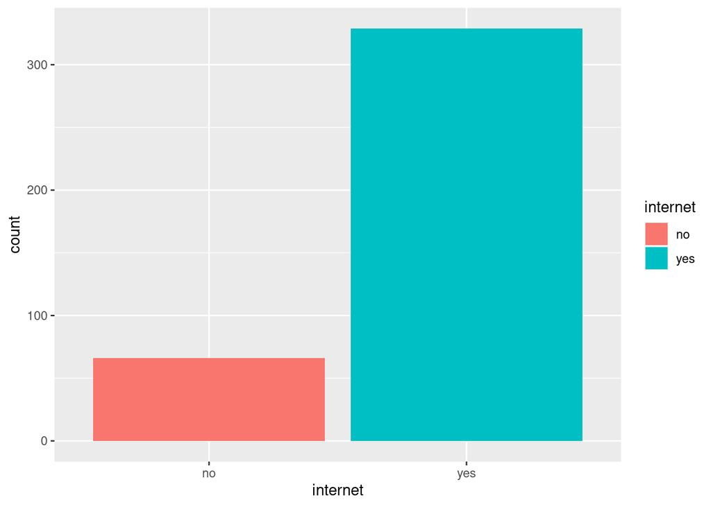

```r
ggplot(data = student) +
       geom_bar(mapping = aes(x=internet, fill=internet))
```

```r
# ggsave("display.22.internet.png")
student$internet = as.factor(student$internet)

############################################################################################################
############################################################################################################
# 23 romantic - with a romantic relationship (binary: yes or no)

unique(student$romantic)
```

```
## [1] "no"  "yes"
```

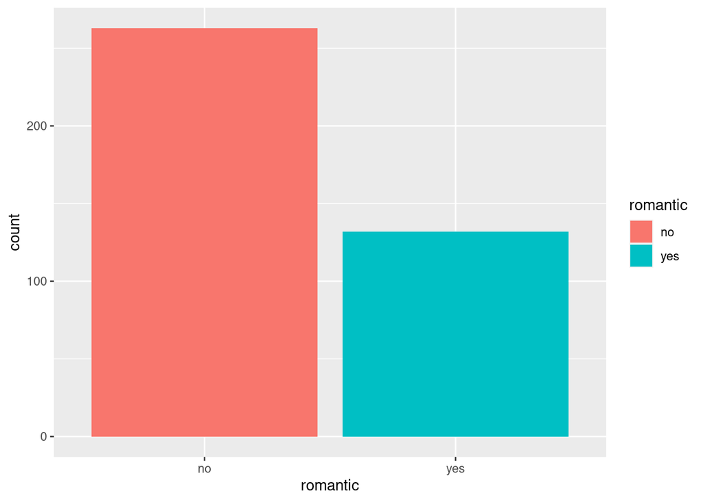

```r
ggplot(data = student) +
       geom_bar(mapping = aes(x=romantic, fill=romantic))
```

```r
# ggsave("display.23.romantic.png")
student$romantic = as.factor(student$romantic)

############################################################################################################
############################################################################################################
# 24 famrel - quality of family relationships (numeric: from 1 - very bad to 5 - excellent)

unique(student$famrel)
```

```
## [1] 4 5 3 1 2
```

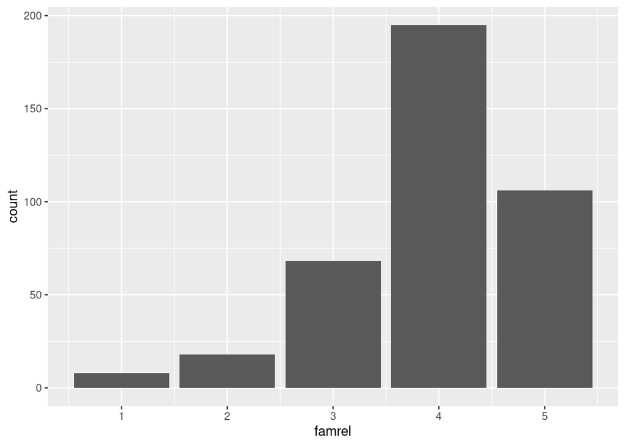

```r
ggplot(data = student) +
       geom_bar(mapping = aes(x=famrel, fill=famrel))
```

```r
# ggsave("display.24.famrel.png")
# i believe that we can keep these as numerical :
student$famrel = as.integer(student$famrel)

############################################################################################################
############################################################################################################
# 25 freetime - free time after school (numeric: from 1 - very low to 5 - very high)

unique(student$freetime)
```

```
## [1] 3 2 4 1 5
```

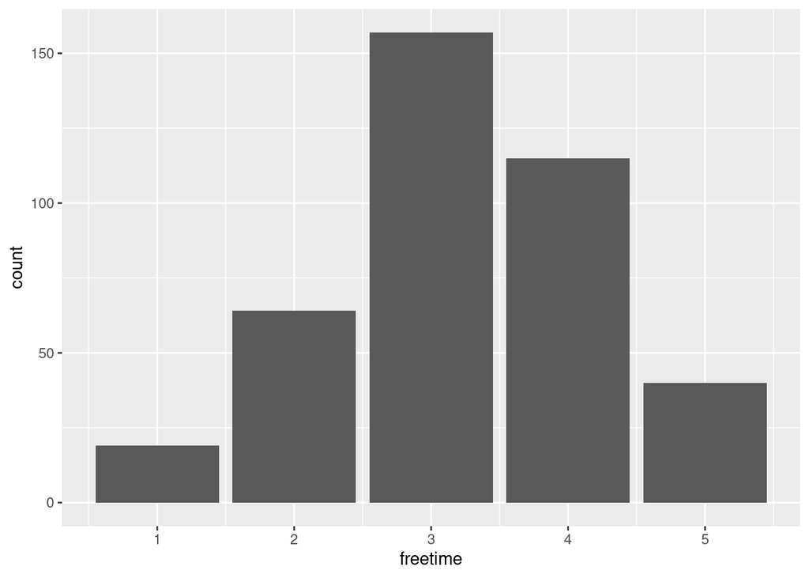

```r
ggplot(data = student) +
       geom_bar(mapping = aes(x=freetime, fill=freetime))
```

```r
# ggsave("display.25.freetime.png")
# i believe that we can keep these as numerical :
student$freetime = as.integer(student$freetime)

############################################################################################################
############################################################################################################
# 26 goout - going out with friends (numeric: from 1 - very low to 5 - very high)

unique(student$goout)
```

```
## [1] 4 3 2 1 5
```

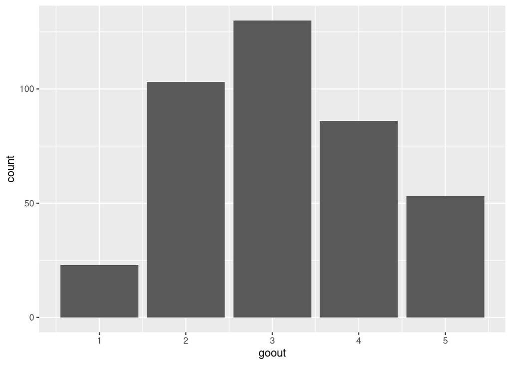

```r
ggplot(data = student) +
       geom_bar(mapping = aes(x=goout, fill=goout))
```

```r
# ggsave("display.26.goout.png")
# i believe that we can keep these as numerical :
student$goout = as.integer(student$goout)

############################################################################################################
############################################################################################################
# 27 Dalc - workday alcohol consumption (numeric: from 1 - very low to 5 - very high)

unique(student$Dalc)
```

```
## [1] 1 2 5 3 4
```

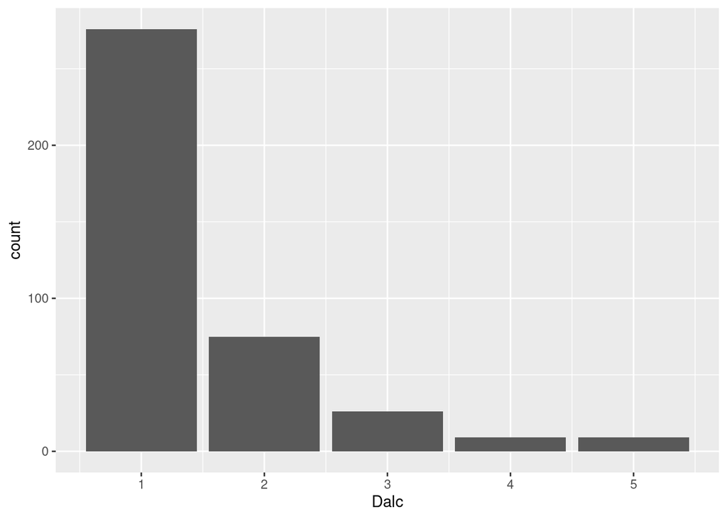

```r
ggplot(data = student) +
       geom_bar(mapping = aes(x=Dalc, fill=Dalc))
```

```r
# ggsave("display.27.Dalc.png")
# i believe that we can keep these as numerical :
student$Dalc = as.integer(student$Dalc)

############################################################################################################
############################################################################################################
# 28 Walc - weekend alcohol consumption (numeric: from 1 - very low to 5 - very high)

unique(student$Walc)
```

```
## [1] 1 3 2 4 5
```

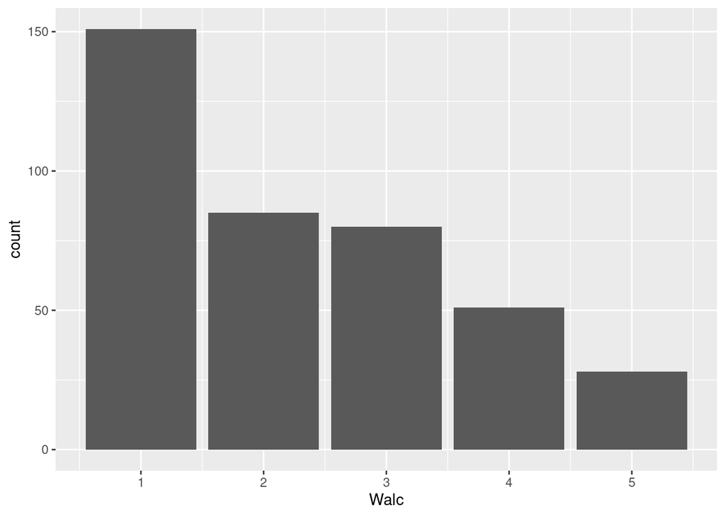

```r
ggplot(data = student) +
       geom_bar(mapping = aes(x=Walc, fill=Walc))
```

```r
# ggsave("display.28.Walc.png")
# i believe that we can keep these as numerical :
student$Walc = as.integer(student$Walc)

############################################################################################################
############################################################################################################
# 29 health - current health status (numeric: from 1 - very bad to 5 - very good)

unique(student$health)
```

```
## [1] 3 5 1 2 4
```

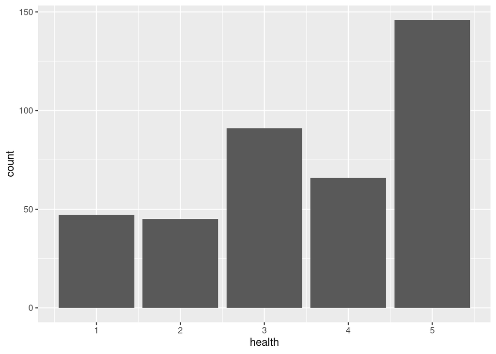

```r
ggplot(data = student) +
       geom_bar(mapping = aes(x=health, fill=health))
```

```r
# ggsave("display.29.health.png")
# i believe that we can keep these as numerical :
student$health = as.integer(student$health)

############################################################################################################
############################################################################################################
# 30 absences - number of school absences (numeric: from 0 to 93)

unique(student$absences)
```

```
##  [1]  6  4 10  2  0 16 14  7  8 25 12 54 18 26 20 56 24 28  5 13 15 22  3 21  1
## [26] 75 30 19  9 11 38 40 23 17
```

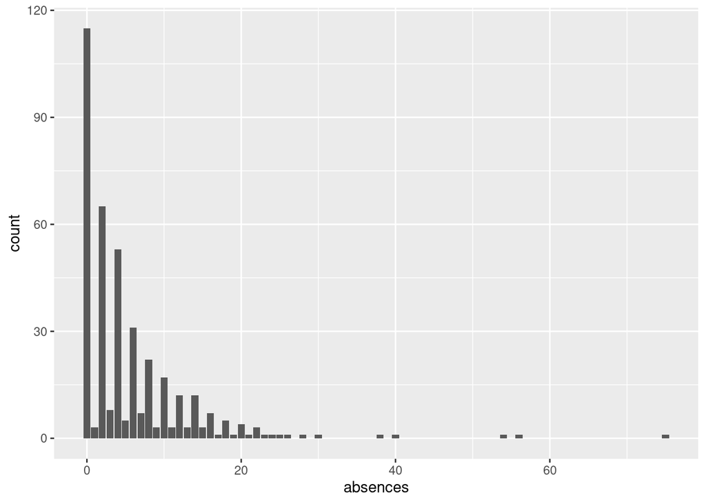

```r
ggplot(data = student) +
       geom_bar(mapping = aes(x=absences, fill=absences))
```

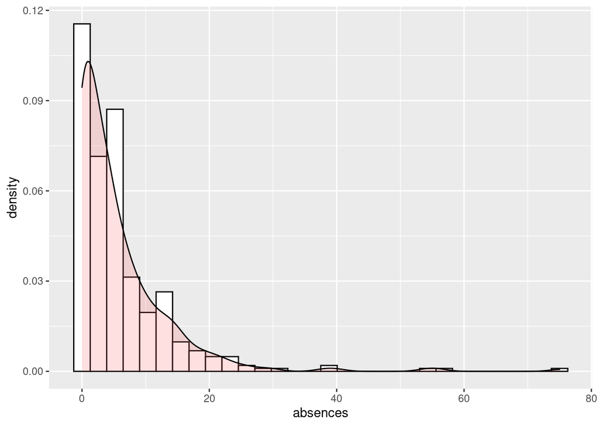

```r
ggplot(data=student, aes(x=absences)) +
      geom_histogram(aes(y=..density..), colour="black", fill="white")+
      geom_density(alpha=.2, fill="#FF6666")
```

```r
# ggsave("display.30.absences.png")
# i believe that we can keep these as numerical :
student$absences = as.integer(student$absences)

############################################################################################################
############################################################################################################
# $ G1        : int  5 5 7 15 6 15 12 6 16 14 ...

unique(student$G1)
```

```
##  [1]  5  7 15  6 12 16 14 10 13  8 11  9 17 19 18  4  3
```